# Bellabet Case Study: Smart Device Analysis

Anh Phuong Dieu Nguyen

May 2026

```r
## Load libraries
library(tidyverse)
library(lubridate)
library(janitor)
library(ggplot2)
```

```r
## Load data
sleep <- read_csv("sleepDay_merged.csv",show_col_types = FALSE)
weight <- read_csv("weightLogInfo_merged.csv",show_col_types = FALSE)
activity_daily <- read_csv("dailyActivity_merged.csv",show_col_types = FALSE)
calories_hourly <- read_csv("hourlyCalories_merged.csv",show_col_types = FALSE)
steps_hourly <- read_csv("hourlySteps_merged.csv",show_col_types = FALSE)
intensity_hourly <- read_csv("hourlyIntensities_merged.csv",show_col_types = FALSE)
```

```r
## Standardize column names
sleep <- clean_names(sleep)
weight <- clean_names(weight)
activity_daily <- clean_names(activity_daily)
calories_hourly <- clean_names(calories_hourly)
steps_hourly <- clean_names(steps_hourly)
intensity_hourly <- clean_names(intensity_hourly)

## Check data type
all <- list(sleep = sleep, weight = weight, activity_daily = activity_daily, calories_hourly = calories_hourly, steps_hourly = steps_hourly, intensity_hourly = intensity_hourly)

lapply(all, function(x) sapply(x, class))
```

```
$sleep
                  id            sleep_day  total_sleep_records total_minutes_asleep    total_time_in_bed
           "numeric"          "character"            "numeric"            "numeric"            "numeric"

$weight
              id             date        weight_kg    weight_pounds              fat              bmi
       "numeric"      "character"        "numeric"        "numeric"        "numeric"        "numeric"
is_manual_report           log_id
       "logical"        "numeric"

$activity_daily
                        id              activity_date                total_steps             total_distance
                 "numeric"                "character"                  "numeric"                  "numeric"
          tracker_distance logged_activities_distance       very_active_distance moderately_active_distance
                 "numeric"                  "numeric"                  "numeric"                  "numeric"
     light_active_distance  sedentary_active_distance        very_active_minutes      fairly_active_minutes
                 "numeric"                  "numeric"                  "numeric"                  "numeric"
    lightly_active_minutes          sedentary_minutes                   calories
                 "numeric"                  "numeric"                  "numeric"

$calories_hourly
           id activity_hour      calories
    "numeric"   "character"     "numeric"

$steps_hourly
           id activity_hour    step_total
    "numeric"   "character"     "numeric"

$intensity_hourly
               id     activity_hour   total_intensity average_intensity
        "numeric"       "character"         "numeric"         "numeric"
```

```r
## Convert date columns
sleep <- sleep |> mutate(sleep_day = as.Date(mdy_hms(sleep_day)))
weight <- weight |> mutate(date = as.Date(mdy_hms(date)))
activity_daily <- activity_daily |> mutate(activity_date = as.Date(mdy(activity_date)))
steps_hourly <- steps_hourly |> mutate(activity_hour =  mdy_hms(activity_hour))
intensity_hourly <- intensity_hourly |> mutate(activity_hour =  mdy_hms(activity_hour))
calories_hourly <- calories_hourly |> mutate(activity_hour =  mdy_hms(activity_hour))

## Check null
lapply(all, function(x) sum(is.na(x)))
```

```
$sleep
[1] 0

$weight
[1] 65

$activity_daily
[1] 0

$calories_hourly
[1] 0

$steps_hourly
[1] 0

$intensity_hourly
[1] 0
```

```r
colSums(is.na(weight))
```

```
              id             date        weight_kg    weight_pounds              fat              bmi
               0                0                0                0               65                0
is_manual_report           log_id
               0                0
```

```r
## Remove column having many missing values
weight <- weight |> select(-fat)

## Remove duplicated values
sleep <- distinct(sleep)
weight <- distinct(weight)
activity_daily <- distinct(activity_daily)
calories_hourly <- distinct(calories_hourly)
intensity_lhoury <- distinct(intensity_hourly)
steps_hourly <- distinct(steps_hourly)

## Remove unnecessary columns
weight <- weight |> select(-is_manual_report, -log_id)
```

```r
## Feature engineering
activity_daily <- activity_daily |>
  mutate(wday = wday(activity_date, label = TRUE),
         activity_level = case_when(
           total_steps < 5000 ~ "Sedentary",
           total_steps < 7500 & total_steps > 5000 ~ "Low Active",
           total_steps < 10000 & total_steps > 7500 ~ "Moderately Active",
           total_steps > 10000 ~ "Active"
         ),
        active_minutes = very_active_minutes + fairly_active_minutes + lightly_active_minutes,
         )

steps_hourly <- steps_hourly |>
  mutate(hour = hour(activity_hour))
calories_hourly <- calories_hourly |>
  mutate(hour = hour(activity_hour))
intensity_hourly <- intensity_hourly |>
  mutate(hour = hour(activity_hour))
```

```r
## Join necesssary tables
daily <- activity_daily |>
  left_join(sleep, by = c("id","activity_date"="sleep_day" )) |>
  mutate(id = as.factor(id))
hourly <- calories_hourly |>
  left_join(steps_hourly, by=c("id","activity_hour","hour")) |>
  left_join(intensity_hourly, by=c("id","activity_hour","hour")) |>
  mutate(id = as.factor(id))
```

```r
## Exploratory Data Analysis
#1. Average sleep per  user

summary <- daily |>
  group_by(id) |>
  summarise(
    avg_sleep = mean(total_minutes_asleep, na.rm = TRUE),
    avg_calories = mean(calories, na.rm=TRUE),
    avg_steps = mean(total_steps, na.rm = TRUE),
    .groups = "drop"
  )
avg_total_sleep <- mean(summary$avg_sleep, na.rm=TRUE)
avg_total_sleep
```

```
[1] 377.4464
```

```r
sleep_plot <- summary |>
  filter(!is.na(avg_sleep))|>
  arrange(avg_sleep) |>
  ggplot(aes(x=reorder(id,avg_sleep),y=avg_sleep)) +
  geom_col(fill="#7CA37C") +
  theme(axis.text.y = element_blank()) +
  coord_flip() +
  geom_hline(yintercept=avg_total_sleep, linewidth = 1, color =  "#bb0a1e") +
  annotate("text", x=3, y=avg_total_sleep, label="Average (377.44 minutes ~ 6.3 hours/day)", size = 3, hjust = -0.1, vjust = -0.5, color="#bb0a1e") +
  geom_hline(yintercept = 420, linewidth = 1) +
  annotate("text", x = 2, y = 420, label = "Sleep Goal (420 minutes ~ 7 hours/day)", size = 3, hjust = -0.1, vjust = -0.5) +
  labs(
    title = "Average sleep duration per day by User",
    x = "Users",
    y = "Average minutes asleep"
  )
```

```r
#2. Average steps per user
avg_total_steps <- mean(summary$avg_steps)
steps_plot <- summary |>
  arrange(avg_steps) |>
  ggplot(aes(x=reorder(id, avg_steps),y=avg_steps)) +
  geom_col(fill="#4169E1") +
  theme(axis.text.y=element_blank()) +
  coord_flip() +
  geom_hline(yintercept=avg_total_steps, linewidth = 1, color =  "#bb0a1e") +
  annotate("text", x=3.5, y=round(avg_total_steps,0), label="Average steps (7520 steps/day)", size = 3, hjust = -0.1, vjust = -0.5, color="#bb0a1e") +
  geom_hline(yintercept = 10000, linewidth =1) +
  annotate("text",x=2,y=10000, label = "Steps Goal (10000 steps/day)", size = 3, hjust = -0.1, vjust = -0.5) +
  labs(
    title = "Avarage steps per day by User",
    x = "Users",
    y = "Average number of steps"
  )
```

```r
#3. Relationship between number of steps and calories burned
steps_calories <- daily |>
  ggplot(
    aes(x=total_steps,y=calories)
  ) +
  geom_jitter(colour = "#4169E1",alpha = 0.6 ) +
  stat_smooth(
    method ="lm",
    formula = y ~ x,
    geom = "smooth",
    color = "black"
  ) +
  labs(
    title = "Relationship between number of steps and calories burned",
    x = "Number of steps per day",
    y = "Calories burned per day "
  )
```

```r
#4. Proportion of activity level
prop_active <- daily |>
  group_by(activity_level) |>
  summarise(count = n(),
  .groups = "drop") |>
  mutate(prop = round(count/sum(count)*100,2))|>
  mutate(highlight = prop == max(prop)) |>
  ggplot(aes(activity_level,prop, fill= highlight)) +
  geom_col(show.legend = FALSE) +
  scale_fill_manual(
    values = c("TRUE" =  "#FDB44E", "FALSE" = "#f8e472",
    guide = "none")
  ) +
  geom_text(aes(label = paste0(prop, "%")), vjust = -0.5, size = 2.5) +
  labs(
    title = "Proportion of different activily levels across all users",
    x = "Activity level",
    y = "Proportion"
  )
```

```r
#5. Relationship between number of steps and sleep duration
steps_sleep <- daily |>
  filter(!is.na(c(total_minutes_asleep))) |>
  ggplot(aes(x=total_steps, y=total_minutes_asleep)) +
  geom_point(colour = "#7ca37c",alpha = 0.6 ) +
  stat_smooth(
    method ="lm",
    formula = y ~ x,
    geom = "smooth",
    color = "black"
  ) +
  labs(
    title = "Relationship between number of steps and sleep duration",
    x="Steps per day",
    y="Sleep duration"
  )
```

```r
#6. Relationship between sedentary level and sleep duration and sleep quality
sedentary_sleep <- daily |>
  filter(!is.na(c(total_minutes_asleep))) |>
  ggplot(aes(x=sedentary_minutes, y=total_minutes_asleep)) +
  geom_point(colour = "#FDB44E",alpha = 0.6 ) +
  stat_smooth(
    method ="lm",
    formula = y ~ x,
    geom = "smooth",
    color = "black"
  ) +
  labs(
    title = "Relationship between sedentary level and sleep duration",
    x="Sedentary minutes",
    y="Sleep duration"
  )
```

```r
#7. BMI information
avg_bmi <- weight |>
  group_by(id) |>
  summarise(
    avg_bmi = mean(bmi)
  ) |>
  mutate(
    healthy = case_when(
      avg_bmi < 18.5 ~ "Underweight",
      avg_bmi <= 24.9 & avg_bmi >= 18.5 ~ "Healthy",
      avg_bmi > 24.9& avg_bmi <= 29.9 ~ "Overweight",
      avg_bmi > 29.9 ~ "Obesity"
      )
    ) |>
  group_by(healthy) |>
  summarize(healthy_count = n()) |>
  mutate(proportion = round(healthy_count/sum(healthy_count)*100,2)) |>
  ggplot(aes(x=healthy, y = proportion, fill = healthy)) +
  geom_bar(stat = "identity", show.legend = FALSE) +
  scale_fill_manual(
    values = c("Underweight" = "#bb0a1e",
    "Healthy" = "#7ca37c",
    "Overweight" = "#bb0a1e",
    "Obesity" = "#bb0a1e")) +
  geom_text(aes(label = paste0(proportion, "%")), vjust = -0.5, size = 2.5) +
  labs(
    title = "Proportion of BMI categories across all users",
    x = "BMI index",
    y = "Proportion of Users"
  )
```

```r
## Recommendations
#1. Number of steps in a week
steps_summary1 <- daily |>
  group_by(wday) |>
  summarise(
    sum_steps1 = sum(total_steps),
    .groups = "drop"
  ) |>
  mutate(
    highlight = sum_steps1 == max(sum_steps1)
  )

steps_week <-
  ggplot(steps_summary1, aes(wday,sum_steps1, fill = highlight)) +
  geom_col() +
  scale_fill_manual(
    values = c("TRUE" = "#0A2472", "FALSE" = "#4169E1"),
    guide = "none"
  ) +
  labs(
    title = "Distribution of number of steps during a week",
    y = "Number of steps",
    x = "Day of Week"
  )
```

```r
#2. Number of steps in a day
steps_summary2 <- hourly |>
  group_by(hour) |>
  summarise(
    sum_steps2 = sum(step_total),
    .groups = "drop"
  ) |>
  mutate(
    highlight = sum_steps2  == max(sum_steps2)
  )

steps_day <-
  ggplot(steps_summary2, aes(hour,sum_steps2, fill = highlight)) +
  geom_col() +
  scale_fill_manual(
    values = c("TRUE" = "#06402B", "FALSE" = "#7CA37C"),
    guide = "none"
  ) +
  labs(
    title = "Distribution of number of steps during a day",
    y = "Number of steps",
    x = "Hour"
  ) +
  scale_x_discrete(
    limits = as.character(0:24)
  )
```

# 1. Introduction

Bellabeat is a succesfull small high-tech manufacturer of health-focused products for women, with beautifully designed technology along with data collection on activity, sleep, stress and reproductive health to empower women with knowledge on their own health and habits. Therefore, Bellabeat is believed to have the potential to become a large player in the global smart device market.

# 2. Business Task

This analysis project will focus on smart fitness data to gain insight how customers are using their smart devices, and in a result, help guide the marketing strategy for the company and provide high-level recommendations for Bellabeat’s marketing strategy.

Key Questions:

- What are some trends in smart device usage?
- How could these trends apply to Bellabeat customers?
- How could these trends help influence Bellabeat market strategy?

Stakeholders:

- **Urška Sršen**: Co-founder and Chief Creative Officer
- **Sando Mur**: Mathematician and Key member of Bellabeat executive team
- **Bellabeat marketing analytics team**

Assessment used:

- Activity level:
  - <5000 steps/day: Inactive/Sedentary
  - 5000-7500: Low active
  - 7500-10000: Moderately active
  - >10000: Active
- BMI categories:
  - <18.5: Underweight
  - 18.5 - 24.9: Healthy weight
  - 25 - 29.9: Overweight
  - >30.0: Obesity

# 3. Data Source

Data tables used:

- sleepDay: sleep duration in minutes (in bed and actually asleep)
- hourlyCalories: hourly number of calories burned per hour per day
- hourlyIntensities: hourly total number of intensity and average intensity per hour per day
- hourlySteps: hourly number of steps per hour per day
- dailyActivity: combined information on total number of steps, calories, activity level by minutes per day
- weightLogInfo: weight (in kg and pound) and BMI index recorded on different dates

Sampling bias: there were only 33 Fitbit users conducted the survey, thus may not fully represent the community of smart devices user.

ROCCC:

- Reliable: Partially
- Original: Yes
- Comprehensive: Partially
- Current: No
- Cited: Yes

# 4. Data Cleaning

## a. Tool Description

Tool used: R

Library used:

- tidyverse: data manipulation, cleaning and transformation
- lubridate: convert date/time formats and extract components like year, month, day, or hour
- janitor: data cleaning with clean columns names and remove duplicate values
- ggplot2: create charts to visualize information

## b. Cleaning and Transformation Steps

Cleaning:

- Standardized column names using `clean_names()`.
- Checked column data types and converted date and time columns into proper datetime formats.
- Identified missing values using `is.na()` and `colSums()`.
- Removed the `fat` column due to excessive missing values.
- Removed duplicate records using `distinct()`.
- Dropped unnecessary columns (`is_manual_report`, `log_id`).

Feature engineering:

- Created a weekday (`wday`) feature from activity dates for weekly activity analysis.
- Categorized users into activity levels based on total daily steps.
- Calculated total active minutes by combining very active, fairly active, and lightly active minutes.
- Extracted hourly information from datetime columns for hourly trend analysis.

Joining tables:

- daily: left join daily activity data with sleep data
- hourly: join all hourly data (calories, steps and intensities)

# 5. Data Analysis

## a. Smart device user’s BMI overview

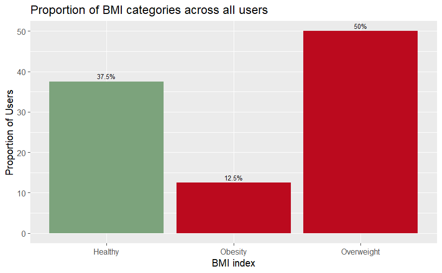

```r
print(avg_bmi)
```

Around 2/3 of smart devices users in this survey are overweight and/or obese while none of them are underweight. This reflects the difference in the level of health awareness and smart device need towards the underweight and overweight issues, in which the overweight might be more aware and more likely to use health-track smart devices. his can be a great opportunity for marketing teams to tackle this gap in the market and target a new group of customers.

## b. Average sleep and steps per day

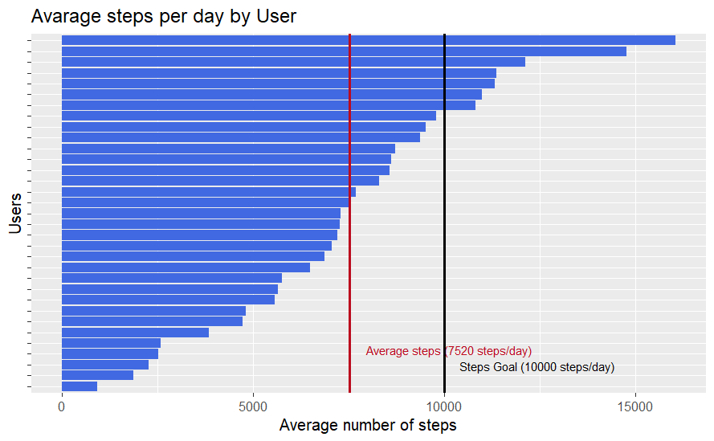

```r
print(steps_plot)
```

While the users in this dataset demonstrate moderately healthy behaviors, with an average of 6.3 hours of sleep and over 7500 steps per day, these figures remain below recommended health guidelines. Therefore, Bellabeat has the potential to introduce new data-driven wellness initiatives and personalized recommendations aimed at helping users improve both sleep quality and daily physical activity.

## c. Number of steps vs. Calories burned

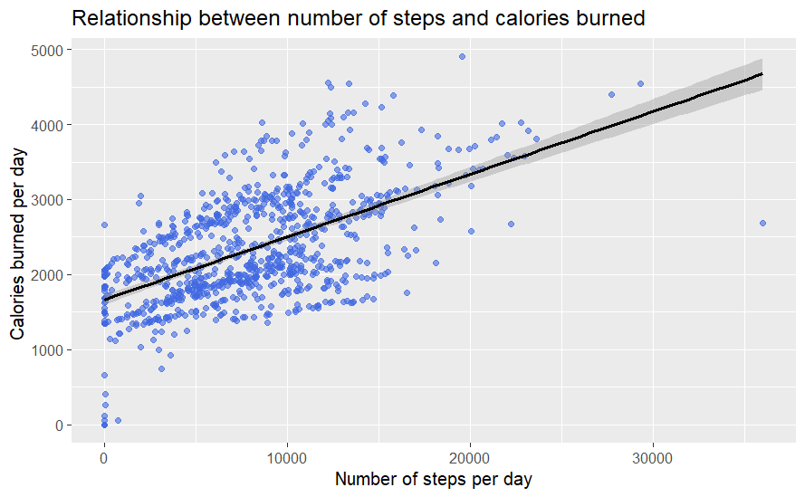

```r
print(steps_calories)
```

A positive regression line represents a strong positive relation between the number of steps and the amount of calories burned, indicating that step count is a reliable indicator of energy expenditure.

## d. Number of steps vs. Sleep duration

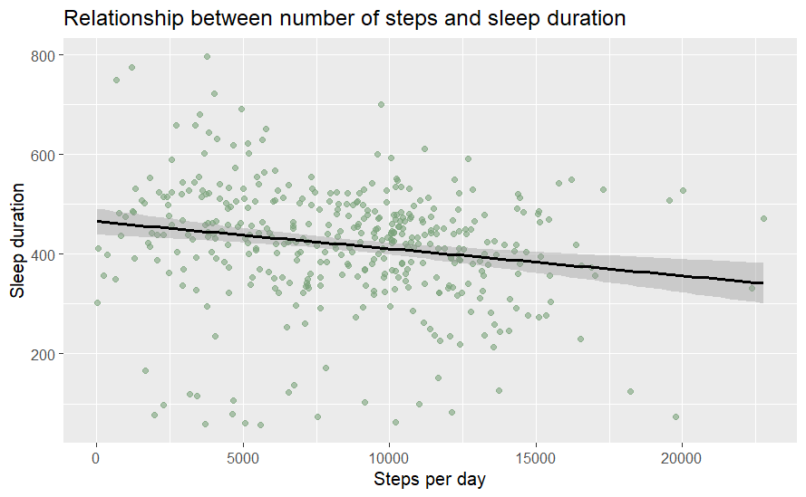

```r
print(steps_sleep)
```

## e. Sedentary duration vs. Sleep duration

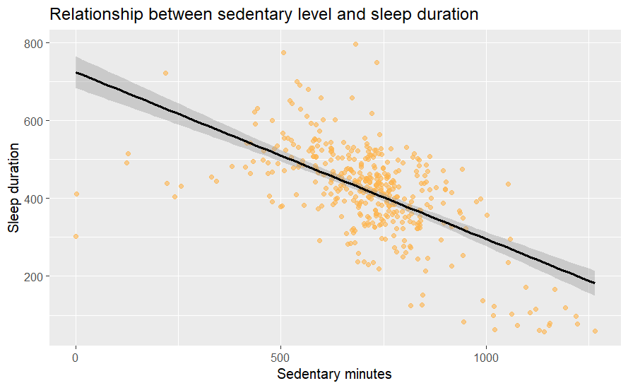

```r
print(sedentary_sleep)
```

It appears to have a strong negative relationship between sedentary minutes and sleep duration, in which the users having more sedentary time in the day will tend to have a shorter sleep duration. Hence, it is opportunity for Bellabeat to pay attention to focus on features and recommendations that encourage users to reduce sedentary behavior and improve sleep habits.

## f. Distribution of steps during a week

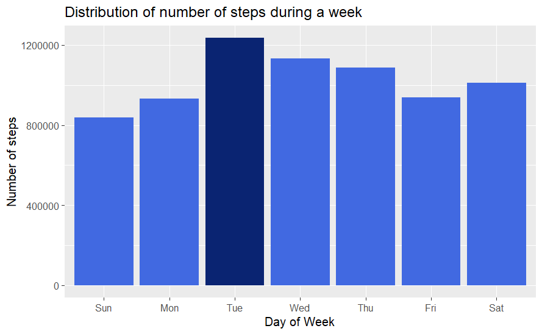

```r
print(steps_week)
```

Tuesday is the day having the highest accumulated number of steps, followed by Wednesday and Thursday, while Sunday and Monday are the days with lowest number.

## g. Distribution of steps during a day

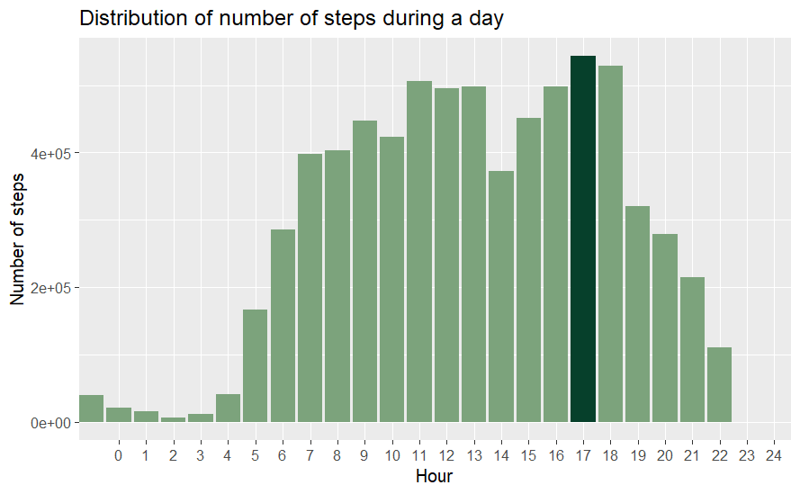

```r
print(steps_day)
```

# 6. Recommendation

## a. New target expansion - Underweight customers

Bellabeat’s marketing campaigns should be developed to promote wellness features specifically designed for underweight users, focusing on:

- Healthy weight gain
- Nutrition tracking
- Wellness monitoring
- Strength and recovery improvement

## b. Personalized reminders for activity and steps goal-tracking features

Bellabeat should implement personalized reminders and adaptive step goals that:

- Encourage movement during peak activity hours (Tuesday, from 4:00 pm to 6:00 pm)
- Send motivational nudges on low-activity days (Sunday and Monday)
- Adjust goals based on user history and activity level

## c. Enhance Sleep Tracking Through Sedentary Behavior Analysis

A marketing campaign can be launched for its sleep monitoring system by integrating sedentary-time tracking and sleep quality analysis, with potential features can be:

- Alerts after prolonged inactivity
- Evening movement reminders
- Insights connecting inactivity patterns to poor sleep

# 7. Conclusions

Through the insights drawn from this analysis of Fitbit smart devices users, Bellabeat can develop the potential features to develop the marketing strategy along with targeting the untouched group of customers to differentiate themselves as a competitor in the smart devices market.